# Skate Summary

### 0.0.3 Diagnostic Plots/Tables

|  | Species | Discards_CAMS | Discards_QM | diff | perc_diff |
| --- | --- | --- | --- | --- | --- |
| 1 | Clearnose skate | 2787720 |  |  |  |
| 2 | Little skate | 15961190 |  |  |  |
| 3 | Rosette skate | 66856 |  |  |  |
| 4 | Barndoor skate | 5113791 |  |  |  |
| 5 | Winter skate | 5835263 |  |  |  |
| 6 | Thorny skate | 533704 |  |  |  |
| 7 | Smooth skate | 1363816 |  |  |  |
| 8 | Skate complex | 31662340 | 13144115 | 18518225 | -58.49 |

2019 Federal Discard Totals by Source

Combined skate discard estimates are much higher for the seven skate species included in the MAPS discard mortality support table (ITIS: 564139, 160855, 564130, 564130, 564136, 564151, 564149 and 564145) compared to the 11 used for QM (160845, 160846, 160848, 160855, 564037, 564130, 564136, 564139, 564145, 564149, 564151).

Probably due to differences in gear types and discard mortality rates which I believe are just one value across skates for QM.

|  | Species | Discards |
| --- | --- | --- |
| 1 | Clearnose skate | 5324166 |
| 2 | Little skate | 426613 |
| 3 | Rosette skate | 1483 |
| 4 | Barndoor skate | 1207579 |
| 5 | Winter skate | 179501 |
| 6 | Thorny skate | 387864 |
| 7 | Smooth skate | 171120 |

2019 CAMS State Discard Totals

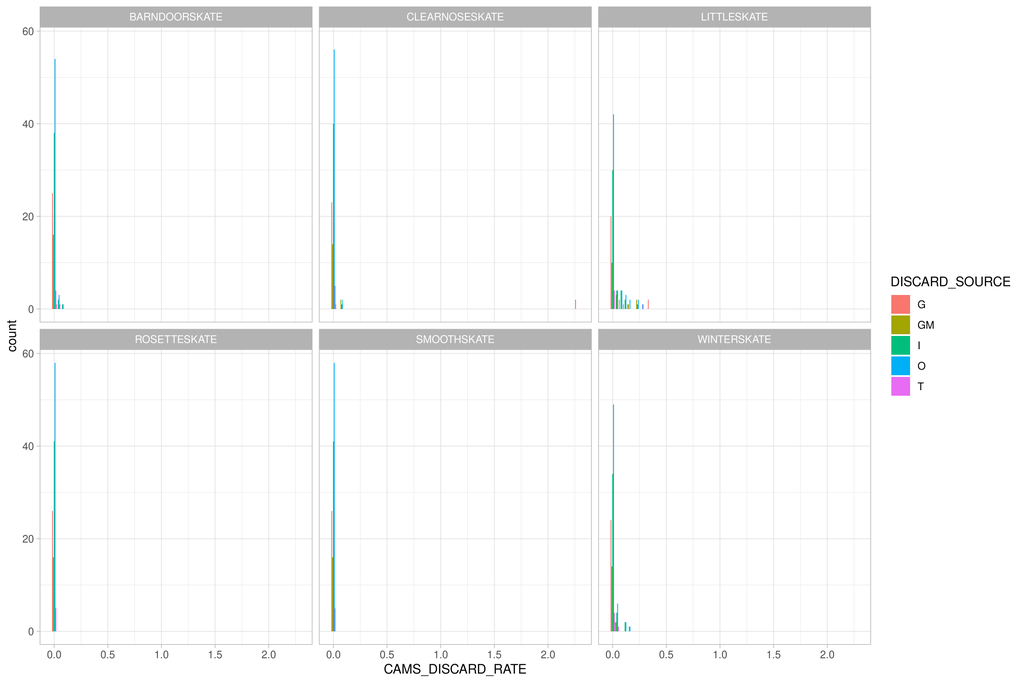

Histogram of Discard Rates by Species, Strata and Discard Source for Federal trips

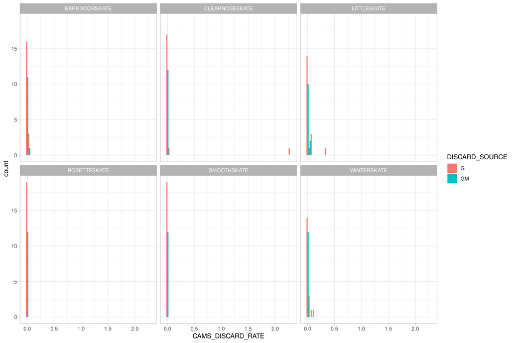

Histogram of Discard Rates by Species, Strata and Discard Source for State trips

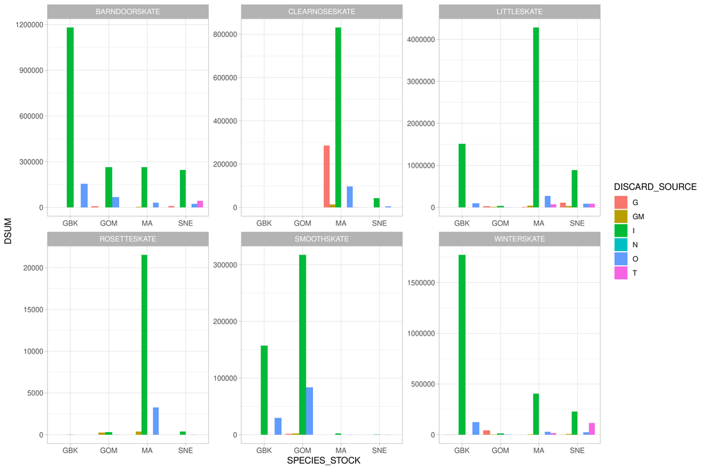

Total Discard Estimates by Species, Stock and Discard Source for Federal trips

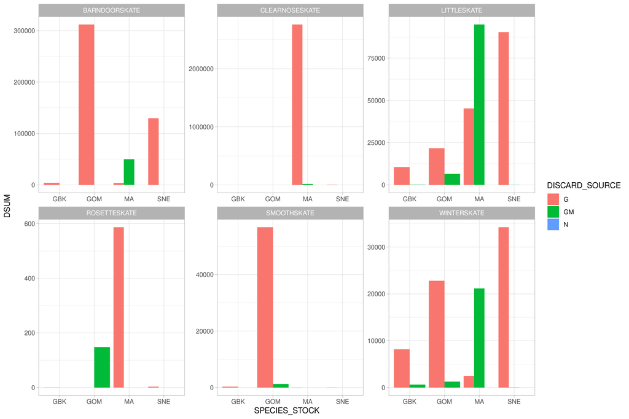

Total Discard Estimates by Species, Stock and Discard Source for State trips

|  | STRATA_FULL | DISCARD_SOURCE | CAMS_DISCARD_RATE | SUBTRIP_KALL | DISC_MORT_RATIO | DISCARD |
| --- | --- | --- | --- | --- | --- | --- |
| 1 | GBK_50_LM_all_all | I | 0.06337 | 18114011 | 0.5 | 573976 |
| 2 | GBK_132_na_LIM_OPEN | I | 0.0083 | 80861888 | 0.5 | 335694 |
| 3 | GOM_50_LM_all_all | I | 0.01766 | 27851605 | 0.5 | 245862 |
| 4 | GBK_132_na_LIM_AA | I | 0.00292 | 137616337 | 0.5 | 200916 |
| 5 | MA_50_LM_all_all | I | 0.0189 | 16262806 | 0.5 | 153666 |
| 6 | SNE_50_LM_all_all | I | 0.01902 | 12503904 | 0.5 | 118901 |
| 7 | SNE_100_XL_all_all | I | 0.02313 | 9249608 | 0.5 | 106966 |
| 8 | GBK_50_SM_all_all | I | 0.00341 | 28532884 | 0.5 | 48720 |
| 9 | SNE_10_na_all_all | T | 0.05087 | 1665797 | 0.5 | 42366 |
| 10 | MA_10_na_all_all | I | 0.04427 | 1590465 | 0.5 | 35202 |

[output cut: 90 more lines]

|  | STRATA_FULL | DISCARD_SOURCE | CAMS_DISCARD_RATE | SUBTRIP_KALL | DISC_MORT_RATIO | DISCARD |
| --- | --- | --- | --- | --- | --- | --- |
| 1 | GOM_100_na_NA_NA | G | 0.01404 | 44301773 | 0.5 | 311010 |
| 2 | SNE_100_na_NA_NA | G | 0.03079 | 8129630 | 0.5 | 125153 |
| 3 | MA_10_na_NA_NA | GM | 0.04427 | 2177741 | 0.5 | 48200 |
| 4 | SNE_50_na_NA_NA | G | 0.01405 | 620791 | 0.5 | 4360 |
| 5 | MA_50_na_NA_NA | G | 0.00606 | 1280035 | 0.5 | 3878 |
| 6 | GBK_100_na_NA_NA | G | 0.00239 | 2363940 | 0.5 | 2822 |
| 7 | MA_0_dredge_na_NA_NA | GM | 4e-05 | 41943865 | 1 | 1524 |
| 8 | GBK_50_na_NA_NA | G | 0.03591 | 65119 | 0.5 | 1169 |
| 9 | GOM_50_na_NA_NA | G | 0.01544 | 115857 | 0.5 | 894 |
| 10 | MA_132_na_NA_NA | GM | 0.00032 | 548847 | 0.5 | 88 |

[output cut: 25 more lines]

|  | STRATA_FULL | DISCARD_SOURCE | CAMS_DISCARD_RATE | SUBTRIP_KALL | DISC_MORT_RATIO | DISCARD |
| --- | --- | --- | --- | --- | --- | --- |
| 1 | MA_50_LM_all_all | I | 0.07768 | 16262806 | 0.5 | 631630 |
| 2 | MA_0_trawlbot_na_all_all | G | 2.27276 | 113314 | 1 | 257536 |
| 3 | MA_132_na_LIM_AA | I | 0.00104 | 150202158 | 0.5 | 78435 |
| 4 | MA_50_SM_all_all | I | 0.00304 | 43061324 | 0.5 | 65546 |
| 5 | MA_0_dredge_na_all_all | I | 0.00015 | 203848631 | 1 | 31147 |
| 6 | SNE_50_LM_all_all | I | 0.00489 | 12503904 | 0.5 | 30574 |
| 7 | MA_100_na_all_all | G | 0.0388 | 1439252 | 0.5 | 27925 |
| 8 | MA_50_LM_GEN_OPEN | GM | 0.07743 | 179085 | 0.5 | 6933 |
| 9 | MA_50_LM_GEN_AA | GM | 0.07743 | 170312 | 0.5 | 6594 |
| 10 | SNE_50_SM_all_all | I | 0.00065 | 17901654 | 0.5 | 5830 |

[output cut: 90 more lines]

|  | STRATA_FULL | DISCARD_SOURCE | CAMS_DISCARD_RATE | SUBTRIP_KALL | DISC_MORT_RATIO | DISCARD |
| --- | --- | --- | --- | --- | --- | --- |
| 1 | MA_100_na_NA_NA | G | 0.0388 | 105718152 | 0.5 | 2051177 |
| 2 | MA_0_trawlbot_na_NA_NA | G | 2.27276 | 308190 | 1 | 700442 |
| 3 | MA_50_na_NA_NA | G | 0.01565 | 1280035 | 0.5 | 10016 |
| 4 | MA_0_handgear_na_NA_NA | GM | 0.00311 | 2495939 | 1 | 7769 |
| 5 | MA_0_dredge_na_NA_NA | GM | 0.00015 | 41943865 | 1 | 6377 |
| 6 | SNE_100_na_NA_NA | G | 0.00081 | 8129630 | 0.5 | 3297 |
| 7 | MA_10_na_NA_NA | GM | 0.00122 | 2177741 | 0.5 | 1332 |
| 8 | SNE_50_na_NA_NA | G | 0.0029 | 620791 | 0.5 | 901 |
| 9 | MA_132_na_NA_NA | GM | 0.00089 | 548847 | 0.5 | 244 |
| 10 | GBK_0_dredge_na_NA_NA | GM | 0 | 289699 | 1 | 0 |

[output cut: 25 more lines]

|  | STRATA_FULL | DISCARD_SOURCE | CAMS_DISCARD_RATE | SUBTRIP_KALL | DISC_MORT_RATIO | DISCARD |
| --- | --- | --- | --- | --- | --- | --- |
| 1 | MA_132_na_LIM_OPEN | I | 0.08176 | 41166464 | 0.48 | 1615568 |
| 2 | MA_50_LM_all_all | I | 0.24806 | 16262806 | 0.22 | 887502 |
| 3 | GBK_132_na_LIM_AA | I | 0.00983 | 137616337 | 0.48 | 649416 |
| 4 | MA_132_na_LIM_AA | I | 0.00894 | 150202158 | 0.48 | 644230 |
| 5 | GBK_132_na_LIM_OPEN | I | 0.01409 | 80861888 | 0.48 | 547042 |
| 6 | MA_0_dredge_na_all_all | I | 0.00209 | 203848631 | 1 | 426514 |
| 7 | SNE_50_LM_all_all | I | 0.12916 | 12503904 | 0.22 | 355308 |
| 8 | SNE_50_SM_all_all | I | 0.0774 | 17901654 | 0.22 | 304822 |
| 9 | MA_132_na_GEN_OPEN | I | 0.11366 | 5375845 | 0.48 | 293284 |
| 10 | MA_50_SM_all_all | I | 0.02655 | 43061324 | 0.22 | 251476 |

[output cut: 90 more lines]

|  | STRATA_FULL | DISCARD_SOURCE | CAMS_DISCARD_RATE | SUBTRIP_KALL | DISC_MORT_RATIO | DISCARD |
| --- | --- | --- | --- | --- | --- | --- |
| 1 | MA_0_dredge_na_NA_NA | GM | 0.00209 | 41943865 | 1 | 87680 |
| 2 | SNE_0_trawlbot_na_NA_NA | G | 0.35263 | 164086 | 1 | 57862 |
| 3 | MA_0_trawlbot_na_NA_NA | G | 0.08507 | 308190 | 1 | 26219 |
| 4 | SNE_100_na_NA_NA | G | 0.00478 | 8129630 | 0.5 | 19424 |
| 5 | MA_50_na_NA_NA | G | 0.0677 | 1280035 | 0.22 | 19065 |
| 6 | GOM_100_na_NA_NA | G | 0.00051 | 44301773 | 0.5 | 11374 |
| 7 | SNE_50_na_NA_NA | G | 0.08122 | 620791 | 0.22 | 11093 |
| 8 | GOM_0_dredge_na_NA_NA | G | 0.00234 | 4394388 | 1 | 10277 |
| 9 | GBK_100_na_NA_NA | G | 0.00858 | 2363940 | 0.5 | 10146 |
| 10 | MA_132_na_NA_NA | GM | 0.02452 | 548847 | 0.48 | 6459 |

[output cut: 25 more lines]

|  | STRATA_FULL | DISCARD_SOURCE | CAMS_DISCARD_RATE | SUBTRIP_KALL | DISC_MORT_RATIO | DISCARD |
| --- | --- | --- | --- | --- | --- | --- |
| 1 | MA_50_LM_all_all | I | 0.00223 | 16262806 | 0.5 | 18107 |
| 2 | MA_50_SM_all_all | I | 0.00016 | 43061324 | 0.5 | 3436 |
| 3 | SNE_50_SM_all_all | I | 4e-05 | 17901654 | 0.5 | 384 |
| 4 | GOM_132_na_GEN_OPEN | I | 0.00019 | 3169014 | 0.5 | 303 |
| 5 | GOM_132_na_all_all | GM | 0.00019 | 2336364 | 0.5 | 223 |
| 6 | MA_50_LM_GEN_OPEN | GM | 0.00222 | 179085 | 0.5 | 199 |
| 7 | MA_50_LM_GEN_AA | GM | 0.00222 | 170312 | 0.5 | 189 |
| 8 | GOM_132_na_LIM_all | GM | 0.00019 | 178095 | 0.5 | 17 |
| 9 | GBK_50_SM_all_all | I | 0 | 28532884 | 0.5 | 16 |
| 10 | GOM_132_na_LIM_AA | GM | 0.00019 | 152605 | 0.5 | 15 |

[output cut: 90 more lines]

|  | STRATA_FULL | DISCARD_SOURCE | CAMS_DISCARD_RATE | SUBTRIP_KALL | DISC_MORT_RATIO | DISCARD |
| --- | --- | --- | --- | --- | --- | --- |
| 1 | MA_50_na_NA_NA | G | 0.00092 | 1280035 | 0.5 | 587 |
| 2 | GOM_132_na_NA_NA | GM | 0.00019 | 1542626 | 0.5 | 148 |
| 3 | SNE_50_na_NA_NA | G | 1e-05 | 620791 | 0.5 | 3 |
| 4 | GBK_0_dredge_na_NA_NA | GM | 0 | 289699 | 1 | 0 |
| 5 | GBK_0_handgear_na_NA_NA | G | 0 | 252218 | 1 | 0 |
| 6 | GBK_0_pottrap_na_NA_NA | GM | 0 | 175672 | 1 | 0 |
| 7 | GBK_100_na_NA_NA | G | 0 | 2363940 | 0.5 | 0 |
| 8 | GBK_50_na_NA_NA | G | 1e-05 | 65119 | 0.5 | 0 |
| 9 | GOM_0_dredge_na_NA_NA | G | 0 | 4394388 | 1 | 0 |
| 10 | GOM_0_handgear_na_NA_NA | G | 0 | 2638493 | 1 | 0 |

[output cut: 25 more lines]

|  | STRATA_FULL | DISCARD_SOURCE | CAMS_DISCARD_RATE | SUBTRIP_KALL | DISC_MORT_RATIO | DISCARD |
| --- | --- | --- | --- | --- | --- | --- |
| 1 | GOM_50_LM_all_all | I | 0.01862 | 27851605 | 0.6 | 311166 |
| 2 | GBK_50_LM_all_all | I | 0.0116 | 18114011 | 0.6 | 126074 |
| 3 | GBK_132_na_LIM_AA | I | 0.00039 | 137616337 | 0.5 | 26978 |
| 4 | GOM_100_LM_all_all | I | 0.00341 | 1958916 | 0.5 | 3342 |
| 5 | GBK_132_na_LIM_OPEN | I | 7e-05 | 80861888 | 0.5 | 2689 |
| 6 | GOM_132_na_GEN_OPEN | I | 0.00159 | 3169014 | 0.5 | 2522 |
| 7 | MA_132_na_LIM_AA | I | 3e-05 | 150202158 | 0.5 | 2246 |
| 8 | GOM_132_na_all_all | GM | 0.00159 | 2336364 | 0.5 | 1860 |
| 9 | GOM_100_na_all_all | G | 0.00252 | 1044452 | 0.5 | 1315 |
| 10 | GBK_132_na_GEN_OPEN | I | 0.00047 | 2608372 | 0.5 | 610 |

[output cut: 90 more lines]

|  | STRATA_FULL | DISCARD_SOURCE | CAMS_DISCARD_RATE | SUBTRIP_KALL | DISC_MORT_RATIO | DISCARD |
| --- | --- | --- | --- | --- | --- | --- |
| 1 | GOM_100_na_NA_NA | G | 0.00252 | 44301773 | 0.5 | 55796 |
| 2 | GOM_132_na_NA_NA | GM | 0.00159 | 1542626 | 0.5 | 1228 |
| 3 | GOM_50_na_NA_NA | G | 0.0146 | 115857 | 0.6 | 1015 |
| 4 | GBK_50_na_NA_NA | G | 0.00591 | 65119 | 0.6 | 231 |
| 5 | GBK_100_na_NA_NA | G | 8e-05 | 2363940 | 0.5 | 97 |
| 6 | MA_50_na_NA_NA | G | 5e-05 | 1280035 | 0.6 | 35 |
| 7 | SNE_50_na_NA_NA | G | 3e-05 | 620791 | 0.6 | 10 |
| 8 | MA_132_na_NA_NA | GM | 2e-05 | 548847 | 0.5 | 6 |
| 9 | GBK_0_dredge_na_NA_NA | GM | 0 | 289699 | 1 | 0 |
| 10 | GBK_0_handgear_na_NA_NA | G | 0 | 252218 | 1 | 0 |

[output cut: 25 more lines]

|  | STRATA_FULL | DISCARD_SOURCE | CAMS_DISCARD_RATE | SUBTRIP_KALL | DISC_MORT_RATIO | DISCARD |
| --- | --- | --- | --- | --- | --- | --- |
| 1 | GBK_132_na_LIM_AA | I | 0.01688 | 137616337 | 0.34 | 789722 |
| 2 | GBK_132_na_LIM_OPEN | I | 0.01227 | 80861888 | 0.34 | 337303 |
| 3 | GBK_50_LM_all_all | I | 0.15676 | 18114011 | 0.09 | 255552 |
| 4 | GBK_0_dredge_na_all_all | I | 0.00217 | 106151074 | 1 | 229978 |
| 5 | SNE_50_LM_all_all | I | 0.1166 | 12503904 | 0.09 | 131217 |
| 6 | MA_132_na_LIM_OPEN | I | 0.00891 | 41166464 | 0.34 | 124710 |
| 7 | GBK_132_na_GEN_OPEN | I | 0.1249 | 2608372 | 0.34 | 110769 |
| 8 | SNE_0_dredge_na_all_all | T | 0.00277 | 38148645 | 1 | 105654 |
| 9 | MA_0_dredge_na_all_all | I | 0.00046 | 203848631 | 1 | 93411 |
| 10 | MA_50_LM_all_all | I | 0.05655 | 16262806 | 0.09 | 82767 |

[output cut: 90 more lines]

|  | STRATA_FULL | DISCARD_SOURCE | CAMS_DISCARD_RATE | SUBTRIP_KALL | DISC_MORT_RATIO | DISCARD |
| --- | --- | --- | --- | --- | --- | --- |
| 1 | SNE_100_na_NA_NA | G | 0.02471 | 8129630 | 0.14 | 28118 |
| 2 | MA_0_dredge_na_NA_NA | GM | 0.00046 | 41943865 | 1 | 19126 |
| 3 | GOM_0_dredge_na_NA_NA | G | 0.00364 | 4394388 | 1 | 15987 |
| 4 | GBK_100_na_NA_NA | G | 0.02269 | 2363940 | 0.14 | 7510 |
| 5 | GOM_100_na_NA_NA | G | 0.00109 | 44301773 | 0.14 | 6785 |
| 6 | SNE_50_na_NA_NA | G | 0.06592 | 620791 | 0.09 | 3683 |
| 7 | MA_50_na_NA_NA | G | 0.02125 | 1280035 | 0.09 | 2448 |
| 8 | SNE_0_dredge_na_NA_NA | G | 0.00277 | 880699 | 1 | 2439 |
| 9 | MA_10_na_NA_NA | GM | 0.00149 | 2177741 | 0.5 | 1619 |
| 10 | GOM_132_na_NA_NA | GM | 0.00215 | 1542626 | 0.34 | 1126 |

[output cut: 25 more lines]

|  | DISCARD_SOURCE | CAMS_GEAR_GROUP | SPECIES_STOCK | D | K | Drate | Dmort |
| --- | --- | --- | --- | --- | --- | --- | --- |
| 1 | I | 50 | GBK | 622695 | 46646895 | 0.0465 | 0.5 |
| 2 | I | 132 | GBK | 542278 | 223422085 | 0.0037 | 0.5 |
| 3 | I | 50 | GOM | 245862 | 29313558 | 0.0167 | 0.5 |
| 4 | I | 50 | MA | 167897 | 59324130 | 0.0113 | 0.5 |
| 5 | I | 50 | SNE | 137816 | 30405558 | 0.0109 | 0.5 |
| 6 | O | 50 | GBK | 129818 | 6560682 | 0.0578 | 0.5 |
| 7 | I | 100 | SNE | 106966 | 10153347 | 0.0138 | 0.5 |
| 8 | O | 50 | GOM | 64304 | 8613715 | 0.0174 | 0.5 |
| 9 | T | 10 | SNE | 42366 | 1665797 | 0.0509 | 0.5 |
| 10 | I | 10 | MA | 35202 | 1590465 | 0.0443 | 0.5 |

[output cut: 89 more lines]

|  | DISCARD_SOURCE | CAMS_GEAR_GROUP | SPECIES_ESTIMATION_REGION | D | K | Drate | Dmort |
| --- | --- | --- | --- | --- | --- | --- | --- |
| 1 | G | 100 | GOM | 311010 | 44301773 | 0.014 | 0.5 |
| 2 | G | 100 | SNE | 125153 | 8129630 | 0.0308 | 0.5 |
| 3 | GM | 10 | MA | 48200 | 2177741 | 0.0443 | 0.5 |
| 4 | G | 50 | SNE | 4360 | 620791 | 0.014 | 0.5 |
| 5 | G | 50 | MA | 3878 | 1280035 | 0.0061 | 0.5 |
| 6 | G | 100 | GBK | 2822 | 2363940 | 0.0024 | 0.5 |
| 7 | GM | 0_dredge | MA | 1524 | 41943865 | 0 | 1 |
| 8 | G | 50 | GBK | 1169 | 65119 | 0.0359 | 0.5 |
| 9 | G | 50 | GOM | 894 | 115857 | 0.0154 | 0.5 |
| 10 | GM | 132 | MA | 88 | 548847 | 0.0003 | 0.5 |

[output cut: 25 more lines]

|  | DISCARD_SOURCE | CAMS_GEAR_GROUP | SPECIES_STOCK | D | K | Drate | Dmort |
| --- | --- | --- | --- | --- | --- | --- | --- |
| 1 | I | 50 | MA | 697176 | 59324130 | 0.0464 | 0.5 |
| 2 | G | 0_trawlbot | MA | 257631 | 113356 | 2.2728 | 1 |
| 3 | O | 50 | MA | 91556 | 7918044 | 0.0493 | 0.5 |
| 4 | I | 132 | MA | 87789 | 203047386 | 0.0008 | 0.5 |
| 5 | I | 50 | SNE | 36404 | 30405558 | 0.0029 | 0.5 |
| 6 | I | 0_dredge | MA | 31147 | 203848631 | 0.0002 | 1 |
| 7 | G | 100 | MA | 27925 | 1439252 | 0.0388 | 0.5 |
| 8 | GM | 50 | MA | 13527 | 349397 | 0.0774 | 0.5 |
| 9 | I | 100 | MA | 6725 | 17219664 | 0.0011 | 0.5 |
| 10 | I | 100 | SNE | 5935 | 10153347 | 0.0021 | 0.5 |

[output cut: 89 more lines]

|  | DISCARD_SOURCE | CAMS_GEAR_GROUP | SPECIES_ESTIMATION_REGION | D | K | Drate | Dmort |
| --- | --- | --- | --- | --- | --- | --- | --- |
| 1 | G | 100 | MA | 2051177 | 105718152 | 0.0388 | 0.5 |
| 2 | G | 0_trawlbot | MA | 700442 | 308190 | 2.2728 | 1 |
| 3 | G | 50 | MA | 10016 | 1280035 | 0.0156 | 0.5 |
| 4 | GM | 0_handgear | MA | 7769 | 2495939 | 0.0031 | 1 |
| 5 | GM | 0_dredge | MA | 6377 | 41943865 | 0.0002 | 1 |
| 6 | G | 100 | SNE | 3297 | 8129630 | 0.0008 | 0.5 |
| 7 | GM | 10 | MA | 1332 | 2177741 | 0.0012 | 0.5 |
| 8 | G | 50 | SNE | 901 | 620791 | 0.0029 | 0.5 |
| 9 | GM | 132 | MA | 244 | 548847 | 0.0009 | 0.5 |
| 10 | G | 50 | GOM | 0 | 115857 | 0 | 0.5 |

[output cut: 25 more lines]

|  | DISCARD_SOURCE | CAMS_GEAR_GROUP | SPECIES_STOCK | D | K | Drate | Dmort |
| --- | --- | --- | --- | --- | --- | --- | --- |
| 1 | I | 132 | MA | 2597776 | 203047386 | 0.0464 | 0.48 |
| 2 | I | 132 | GBK | 1240840 | 223422085 | 0.0144 | 0.48 |
| 3 | I | 50 | MA | 1138978 | 59324130 | 0.1553 | 0.22 |
| 4 | I | 50 | SNE | 660130 | 30405558 | 0.1044 | 0.22 |
| 5 | I | 0_dredge | MA | 426514 | 203848631 | 0.0021 | 1 |
| 6 | I | 132 | SNE | 197084 | 7473931 | 0.0459 | 0.48 |
| 7 | I | 50 | GBK | 169350 | 46646895 | 0.0281 | 0.22 |
| 8 | O | 50 | MA | 147867 | 7918044 | 0.1638 | 0.22 |
| 9 | G | 0_trawlbot | SNE | 110286 | 967638 | 0.1626 | 1 |
| 10 | O | 132 | MA | 99610 | 14813309 | 0.0416 | 0.48 |

[output cut: 89 more lines]

|  | DISCARD_SOURCE | CAMS_GEAR_GROUP | SPECIES_ESTIMATION_REGION | D | K | Drate | Dmort |
| --- | --- | --- | --- | --- | --- | --- | --- |
| 1 | GM | 0_dredge | MA | 87680 | 41943865 | 0.0021 | 1 |
| 2 | G | 0_trawlbot | SNE | 57862 | 164086 | 0.3526 | 1 |
| 3 | G | 0_trawlbot | MA | 26219 | 308190 | 0.0851 | 1 |
| 4 | G | 100 | SNE | 19424 | 8129630 | 0.0048 | 0.5 |
| 5 | G | 50 | MA | 19065 | 1280035 | 0.0677 | 0.22 |
| 6 | G | 100 | GOM | 11374 | 44301773 | 0.0005 | 0.5 |
| 7 | G | 50 | SNE | 11093 | 620791 | 0.0812 | 0.22 |
| 8 | G | 0_dredge | GOM | 10277 | 4394388 | 0.0023 | 1 |
| 9 | G | 100 | GBK | 10146 | 2363940 | 0.0086 | 0.5 |
| 10 | GM | 132 | MA | 6459 | 548847 | 0.0245 | 0.48 |

[output cut: 25 more lines]

|  | DISCARD_SOURCE | CAMS_GEAR_GROUP | SPECIES_STOCK | D | K | Drate | Dmort |
| --- | --- | --- | --- | --- | --- | --- | --- |
| 1 | I | 50 | MA | 21544 | 59324130 | 0.0014 | 0.5 |
| 2 | O | 50 | MA | 3273 | 7918044 | 0.0014 | 0.5 |
| 3 | GM | 50 | MA | 388 | 349397 | 0.0022 | 0.5 |
| 4 | I | 50 | SNE | 384 | 30405558 | 0 | 0.5 |
| 5 | I | 132 | GOM | 303 | 3169014 | 0.0002 | 0.5 |
| 6 | GM | 132 | GOM | 258 | 2692631 | 0.0002 | 0.5 |
| 7 | O | 50 | SNE | 20 | 2841502 | 0 | 0.5 |
| 8 | I | 50 | GBK | 16 | 46646895 | 0 | 0.5 |
| 9 | I | 132 | GBK | 5 | 223422085 | 0 | 0.5 |
| 10 | O | 132 | GOM | 4 | 47210 | 0.0002 | 0.5 |

[output cut: 89 more lines]

|  | DISCARD_SOURCE | CAMS_GEAR_GROUP | SPECIES_ESTIMATION_REGION | D | K | Drate | Dmort |
| --- | --- | --- | --- | --- | --- | --- | --- |
| 1 | G | 50 | MA | 587 | 1280035 | 0.0009 | 0.5 |
| 2 | GM | 132 | GOM | 148 | 1542626 | 0.0002 | 0.5 |
| 3 | G | 50 | SNE | 3 | 620791 | 0 | 0.5 |
| 4 | G | 50 | GBK | 0 | 65119 | 0 | 0.5 |
| 5 | G | 50 | GOM | 0 | 115857 | 0 | 0.5 |
| 6 | G | 0_dredge | GOM | 0 | 4394388 | 0 | 1 |
| 7 | G | 0_dredge | SNE | 0 | 880699 | 0 | 1 |
| 8 | G | 0_handgear | GBK | 0 | 252218 | 0 | 1 |
| 9 | G | 0_handgear | GOM | 0 | 2638493 | 0 | 1 |
| 10 | G | 0_handgear | SNE | 0 | 1270578 | 0 | 1 |

[output cut: 25 more lines]

|  | DISCARD_SOURCE | CAMS_GEAR_GROUP | SPECIES_STOCK | D | K | Drate | Dmort |
| --- | --- | --- | --- | --- | --- | --- | --- |
| 1 | I | 50 | GOM | 311202 | 29313558 | 0.0176 | 0.6 |
| 2 | I | 50 | GBK | 126201 | 46646895 | 0.0083 | 0.6 |
| 3 | O | 50 | GOM | 82858 | 8613715 | 0.0184 | 0.6 |
| 4 | I | 132 | GBK | 30871 | 223422085 | 0.0004 | 0.5 |
| 5 | O | 50 | GBK | 27925 | 6560682 | 0.0105 | 0.6 |
| 6 | I | 100 | GOM | 3800 | 3853683 | 0.002 | 0.5 |
| 7 | I | 132 | GOM | 2522 | 3169014 | 0.0016 | 0.5 |
| 8 | I | 132 | MA | 2304 | 203047386 | 0 | 0.5 |
| 9 | GM | 132 | GOM | 2143 | 2692631 | 0.0016 | 0.5 |
| 10 | O | 132 | GBK | 1712 | 20867198 | 0.0004 | 0.5 |

[output cut: 89 more lines]

|  | DISCARD_SOURCE | CAMS_GEAR_GROUP | SPECIES_ESTIMATION_REGION | D | K | Drate | Dmort |
| --- | --- | --- | --- | --- | --- | --- | --- |
| 1 | G | 100 | GOM | 55796 | 44301773 | 0.0025 | 0.5 |
| 2 | GM | 132 | GOM | 1228 | 1542626 | 0.0016 | 0.5 |
| 3 | G | 50 | GOM | 1015 | 115857 | 0.0146 | 0.6 |
| 4 | G | 50 | GBK | 231 | 65119 | 0.0059 | 0.6 |
| 5 | G | 100 | GBK | 97 | 2363940 | 0.0001 | 0.5 |
| 6 | G | 50 | MA | 35 | 1280035 | 0 | 0.6 |
| 7 | G | 50 | SNE | 10 | 620791 | 0 | 0.6 |
| 8 | GM | 132 | MA | 6 | 548847 | 0 | 0.5 |
| 9 | G | 0_dredge | GOM | 0 | 4394388 | 0 | 1 |
| 10 | G | 0_dredge | SNE | 0 | 880699 | 0 | 1 |

[output cut: 25 more lines]

|  | DISCARD_SOURCE | CAMS_GEAR_GROUP | SPECIES_STOCK | D | K | Drate | Dmort |
| --- | --- | --- | --- | --- | --- | --- | --- |
| 1 | I | 132 | GBK | 1242125 | 223422085 | 0.0378 | 0.34 |
| 2 | I | 50 | GBK | 263133 | 46646895 | 0.1133 | 0.09 |
| 3 | I | 0_dredge | GBK | 229978 | 106151074 | 0.0022 | 1 |
| 4 | I | 132 | MA | 167420 | 203047386 | 0.0035 | 0.34 |
| 5 | I | 50 | SNE | 161788 | 30405558 | 0.0699 | 0.09 |
| 6 | I | 50 | MA | 123991 | 59324130 | 0.0373 | 0.09 |
| 7 | T | 0_dredge | SNE | 105654 | 38148645 | 0.0028 | 1 |
| 8 | I | 0_dredge | MA | 93411 | 203848631 | 0.0005 | 1 |
| 9 | O | 132 | GBK | 64005 | 20867198 | 0.0303 | 0.34 |
| 10 | O | 50 | GBK | 56194 | 6560682 | 0.1424 | 0.09 |

[output cut: 89 more lines]

|  | DISCARD_SOURCE | CAMS_GEAR_GROUP | SPECIES_ESTIMATION_REGION | D | K | Drate | Dmort |
| --- | --- | --- | --- | --- | --- | --- | --- |
| 1 | G | 100 | SNE | 28118 | 8129630 | 0.0247 | 0.14 |
| 2 | GM | 0_dredge | MA | 19126 | 41943865 | 0.0005 | 1 |
| 3 | G | 0_dredge | GOM | 15987 | 4394388 | 0.0036 | 1 |
| 4 | G | 100 | GBK | 7510 | 2363940 | 0.0227 | 0.14 |
| 5 | G | 100 | GOM | 6785 | 44301773 | 0.0011 | 0.14 |
| 6 | G | 50 | SNE | 3683 | 620791 | 0.0659 | 0.09 |
| 7 | G | 50 | MA | 2448 | 1280035 | 0.0212 | 0.09 |
| 8 | G | 0_dredge | SNE | 2439 | 880699 | 0.0028 | 1 |
| 9 | GM | 10 | MA | 1619 | 2177741 | 0.0015 | 0.5 |
| 10 | GM | 132 | GOM | 1126 | 1542626 | 0.0021 | 0.34 |

[output cut: 25 more lines]

### 0.0.4 Appendix

For more information regarding stratification variables and discard rates by species see

MAPS.CAMS_STATAREA_STOCK MAPS.CAMS_DISCARD_MORTALITY_STOCK MAPS.CAMS_GEARCODE_STRATA MAPS.CAMS_MASTER_GEAR MAPS.CAMS_OBS_CATCH